# Race/Ethnicity Exposure - City

Author

Aaron R. Williams, Vincent Pancini, and Manu Alcalá Kovalski

Published

March 3, 2025

# Racial/ethnic Exposure

This metric measures the exposure of a given race/ethnicity group to other race/ethnicity groups. The metric is calculated at the census tract level and then aggregated to the place level. We are interested in Hispanic, non-Hispanic Black, non-Hispanic white, and Other Races and Ethnicities.

1. On average, people who are Hispanic live in neighborhoods that are X% non-Hispanic.
2. On average, people who are non-Hispanic Black live in neighborhoods that are X% non-non-Hispanic Black.
3. On average, people who are non-Hispanic white live in neighborhoods that are X% non-non-Hispanic white.
4. On average, people who are Other Races and Ethnicities live in neighborhoods that are x% non-Other Races and Ethnicities.

## Process

1. Pull all non-overlapping race/ethnicity groups needed to create Hispanic, non-Hispanic Black, non-Hispanic white, and Other Races and Ethnicities.
2. Collapse the detailed groups to the four groups of interest.
3. Crosswalk census tracts to census places.
4. Calculate the share of a place’s racial/ethnic group in each tract.
5. Calculate exposure to other racial/ethnic groups:
   - Calculate Hispanic exposure to other three groups.
   - Calculate non-Hispanic Black exposure to other three groups.
   - Calculate non-Hispanic white exposure to other three groups.
   - Calculate Other Races and Ethnicities exposure to other three groups.
6. Validation
7. Add data quality flags
8. Save the data

## Housekeeping

```r
options(scipen = 999)

library(tidyverse)
library(censusapi)
library(urbnthemes)
library(reactable)
library(tidylog)

set_urbn_defaults(style = "print")

source(here::here("06_neighborhoods", "R", "get_vars.R"))
source(here::here("functions", "testing", "evaluate_final_data.R"))
# source(here::here("06_neighborhoods", "R", "census_api_key.R"))
```

## 1. Pull all non-overlapping race/enthnicity groups needed to create Hispanic, non-Hispanic Black, non-Hispanic white, and Other Races and Ethnicities.

The American Community Survey reports detailed race and ethnicity by the following table.

The variable codes for population by race/ethnicity are different for different years. Therefore, we construct a tribble with the variable-year combinations

```r
# Tribble with year-specific ACS codes and corresponding labels
variable_mapping <- tribble(
  ~year, ~code, ~label,
  # 2016 Codes
  2016, "DP05_0066E", "hispanic",
  2016, "DP05_0066M", "hispanic_moe",
  2016, "DP05_0072E", "white_nh",
  2016, "DP05_0072M", "white_nh_moe",
  2016, "DP05_0073E", "black_nh",
  2016, "DP05_0073M", "black_nh_moe",
  2016, "DP05_0074E", "aian_nh",
  2016, "DP05_0074M", "aian_nh_moe",
  2016, "DP05_0075E", "asian_nh",
  2016, "DP05_0075M", "asian_nh_moe",
  2016, "DP05_0076E", "nhpi_nh",
  2016, "DP05_0076M", "nhpi_nh_moe",
  2016, "DP05_0077E", "census_other_nh",
  2016, "DP05_0077M", "census_other_nh_moe",
  2016, "DP05_0078E", "two_or_more_nh",
  2016, "DP05_0078M", "two_or_more_nh_moe",
  2018, "DP05_0071E", "hispanic",
  2018, "DP05_0071M", "hispanic_moe",
  2018, "DP05_0077E", "white_nh",
  2018, "DP05_0077M", "white_nh_moe",
  2018, "DP05_0078E", "black_nh",
  2018, "DP05_0078M", "black_nh_moe",
  2018, "DP05_0079E", "aian_nh",
  2018, "DP05_0079M", "aian_nh_moe",
  2018, "DP05_0080E", "asian_nh",
  2018, "DP05_0080M", "asian_nh_moe",
  2018, "DP05_0081E", "nhpi_nh",
  2018, "DP05_0081M", "nhpi_nh_moe",
  2018, "DP05_0082E", "census_other_nh",
  2018, "DP05_0082M", "census_other_nh_moe",
  2018, "DP05_0083E", "two_or_more_nh",
  2018, "DP05_0083M", "two_or_more_nh_moe",
  2021, "DP05_0071E", "hispanic",
  2021, "DP05_0071M", "hispanic_moe",
  2021, "DP05_0077E", "white_nh",
  2021, "DP05_0077M", "white_nh_moe",
  2021, "DP05_0078E", "black_nh",
  2021, "DP05_0078M", "black_nh_moe",
  2021, "DP05_0079E", "aian_nh",
  2021, "DP05_0079M", "aian_nh_moe",
  2021, "DP05_0080E", "asian_nh",
  2021, "DP05_0080M", "asian_nh_moe",
  2021, "DP05_0081E", "nhpi_nh",
  2021, "DP05_0081M", "nhpi_nh_moe",
  2021, "DP05_0082E", "census_other_nh",
  2021, "DP05_0082M", "census_other_nh_moe",
  2021, "DP05_0083E", "two_or_more_nh",
  2021, "DP05_0083M", "two_or_more_nh_moe",
  2023, "DP05_0076E", "hispanic",
  2023, "DP05_0076M", "hispanic_moe",
  2023, "DP05_0082E", "white_nh",
  2023, "DP05_0082M", "white_nh_moe",
  2023, "DP05_0083E", "black_nh",
  2023, "DP05_0083M", "black_nh_moe",
  2023, "DP05_0084E", "aian_nh",
  2023, "DP05_0084M", "aian_nh_moe",
  2023, "DP05_0085E", "asian_nh",
  2023, "DP05_0085M", "asian_nh_moe",
  2023, "DP05_0086E", "nhpi_nh",
  2023, "DP05_0086M", "nhpi_nh_moe",
  2023, "DP05_0087E", "census_other_nh",
  2023, "DP05_0087M", "census_other_nh_moe",
  2023, "DP05_0088E", "two_or_more_nh",
  2023, "DP05_0088M", "two_or_more_nh_moe"
)

pull_and_rename <- function(year, geography = "tract") {
  vars <- variable_mapping %>%
    filter(year == {{ year }}) %>%
    pull(code)

  tracts_raw <-
    get_vars(
      year = year, vars = vars,
      geography = geography, source = "acs/acs5/profile"
    ) |>
    mutate(year = {{ year }})


  rename_lookup <- variable_mapping %>%
    filter(year == {{ year }}) %>%
    select(code, label) %>%
    distinct() %>%
    deframe()

  # Rename columns using the lookup
  tracts <- tracts_raw %>%
    rename_with(~ rename_lookup[.x], .cols = names(rename_lookup)) |>
    rename(people = B01003_001E) # from get_vars()


  return(tracts)
}

years <- c(2016, 2018, 2021, 2023)

if(!file.exists(here::here("06_neighborhoods/race-ethnicity-exposure/data/tracts.csv"))){
  tracts_raw <- map(years, ~ pull_and_rename(.x)) |>
  list_rbind() |>
  relocate(year, .before = everything())


if(!dir.exists(here::here("06_neighborhoods/race-ethnicity-exposure/data"))){
  dir.create(here::here("06_neighborhoods/race-ethnicity-exposure/data"))
}
write_csv(tracts_raw, here::here("06_neighborhoods/race-ethnicity-exposure/data/tracts.csv"))

}
```

Since the code chunk above takes roughly 30 minutes to run, we export and import the data back

```r
tracts_raw <- read_csv(here::here("06_neighborhoods/race-ethnicity-exposure/data/tracts.csv"))
```

Some tracts don’t have any population. We drop those tracts.

```r
tracts <- tracts_raw %>%
  tidylog::filter(people > 0)
```

Certain estimates are controlled. The margins of errors for these estimates will appear as `-555555555` but [can be treated as zero](https://www.census.gov/content/dam/Census/programs-surveys/acs/guidance/training-presentations/20180418_MOE_Webinar_Transcript.pdf). [Here are all of the special codes.](https://www.census.gov/data/developers/data-sets/acs-1year/data-notes.html)

```r
tracts <- tracts %>%
  mutate(hispanic_moe = if_else(hispanic_moe == -555555555, 0, hispanic_moe))
```

We calculate the coefficients of variation for each variable.

```r
tracts_cv <- tracts %>%
  mutate(
    hispanic_cv = (hispanic_moe / 1.645) / hispanic,
    black_nh_cv = (black_nh_moe / 1.645) / black_nh,
    white_nh_cv = (white_nh_moe / 1.645) / white_nh,
    aian_nh_cv = (aian_nh_moe / 1.645) / aian_nh,
    nhpi_nh_cv = (nhpi_nh_moe / 1.645) / nhpi_nh,
    census_other_nh_cv = (census_other_nh_moe / 1.645) / census_other_nh,
    two_or_more_nh_cv = (two_or_more_nh_moe / 1.645) / two_or_more_nh
  )
```

Most tracts have very large coefficients of variation. Some of these tracts will be in census places that we suppress. Others will be included in calculations but have lower quality scores.

We also combine AIAN, NHPI, Other, and Two or More races to reduce the CVs. Finally, averaging on the place level will reduce some of the imprecision. The following table shows the share of tracts with coefficients of variation greater than 0.4, a very poor CV for each race/ethnicity group. The shares are very high.

```r
tracts_cv %>%
  summarize(
    hispanic = mean(hispanic_cv >= 0.4),
    black_nh = mean(black_nh_cv >= 0.4),
    white_nh = mean(white_nh_cv >= 0.4),
    asian_nh = mean(asian_nh >= 0.4),
    aian_nh = mean(aian_nh_cv >= 0.4),
    nhpi_nh = mean(nhpi_nh_cv >= 0.4),
    census_other_nh = mean(census_other_nh_cv >= 0.4),
    two_or_more_nh = mean(two_or_more_nh_cv >= 0.4),
    .by = c(year)
  )
```

```
# A tibble: 4 × 9
   year hispanic black_nh white_nh asian_nh aian_nh nhpi_nh census_other_nh
  <dbl>    <dbl>    <dbl>    <dbl>    <dbl>   <dbl>   <dbl>           <dbl>
1  2016    0.422    0.549   0.0477    0.801   0.969   0.996           0.998
2  2018    0.407    0.549   0.0479    0.806   0.970   0.996           0.998
3  2021    0.480    0.631   0.0656    0.769   0.976   0.997           0.998
4  2023    0.447    0.626   0.0658    0.781   0.976   0.997           0.998
# ℹ 1 more variable: two_or_more_nh <dbl>
```

Other Races and Ethnicities includes Non-Hispanic American Indian and Alaska Native alone (`aian_nh`), Non-Hispanic Asian alone (`asian_nh`), non-Hispanic Native Hawaiian and Other Pacific Island alone (`nhpi_nh`), non-Hispanic other (`other_nh`), and non-Hispanic two or more (`two_or_more_nh`).

```r
tracts <- tracts %>%
  mutate(
    other_nh =
      aian_nh +
        asian_nh +
        nhpi_nh +
        census_other_nh +
        two_or_more_nh,
    other_nh_moe =
      sqrt(
        aian_nh_moe^2 +
          asian_nh_moe^2 +
          nhpi_nh_moe^2 +
          census_other_nh_moe^2 +
          two_or_more_nh_moe^2
      )
  )
```

[This Census presentation](https://www.census.gov/content/dam/Census/programs-surveys/acs/guidance/training-presentations/20180418_MOE_Webinar_Transcript.pdf) recommends using the maximum margin of error when aggregating multiple zero estimates.

> One way this approximation can differ from the actual MOE is if you were aggregating multiple zero estimates. In this case, the approximate MOE could diverge from the actual margin of error. And so our recommendation is to only include one zero estimate margin of error and include the largest one.

```r
# pivot the point estimates
values <- tracts %>%
  select(
    year,
    state,
    county,
    tract,
    aian_nh,
    asian_nh,
    nhpi_nh,
    census_other_nh,
    two_or_more_nh
  ) %>%
  pivot_longer(
    cols = c(-year, -state, -county, -tract),
    names_to = "group",
    values_to = "value"
  )

# pivot the margins of error
moes <- tracts %>%
  select(
    year,
    state,
    county,
    tract,
    aian_nh_moe,
    asian_nh_moe,
    nhpi_nh_moe,
    census_other_nh_moe,
    two_or_more_nh_moe
  ) %>%
  pivot_longer(
    cols = c(-year, -state, -county, -tract),
    names_to = "group",
    values_to = "moe"
  ) %>%
  mutate(group = str_replace(group, "_moe", ""))

# combine the point estimates and margins of error
other_moe <- left_join(values, moes, by = c("year", "state", "county", "tract", "group"))

rm(moes, values)

# keep MOE for non-zero estimates and keep the largest MOE for zero estimates
# NOTE: we're only keeping the largest MOE once
other_moe <- other_moe %>%
  group_by(year, state, county, tract) %>%
  mutate(moe_rank = row_number(desc(moe))) %>%
  mutate(moe_rank = if_else(value == 0, moe_rank, 5L)) %>%
  mutate(moe_rank = if_else(moe_rank == min(moe_rank), moe_rank, 0L)) %>%
  filter(value != 0 | moe_rank != 0) %>%
  select(-moe_rank)

# combine the margins of error
other_moe <- other_moe %>%
  summarize(other_nh_moe_reduced = sqrt(sum(moe^2))) %>%
  ungroup()

# append to the original data set
tracts <- left_join(tracts, other_moe, by = c("year", "state", "county", "tract"))
```

We convert margins of error to standard errors using 1.645 as the critical value ([page 3](https://www2.census.gov/programs-surveys/acs/tech_docs/accuracy/2018_ACS_Accuracy_Document_Worked_Examples.pdf?))

```r
tracts <- tracts %>%
  mutate(
    hispanic_se = hispanic_moe / 1.645,
    black_nh_se = black_nh_moe / 1.645,
    other_nh_se = other_nh_moe / 1.645,
    white_nh_se = white_nh_moe / 1.645,
    other_nh_se_reduced = other_nh_moe_reduced / 1.645
  )
```

```r
tracts <- tracts %>%
  select(
    year,
    state,
    county,
    tract,
    people,
    hispanic,
    black_nh,
    other_nh,
    white_nh,
    hispanic_se,
    black_nh_se,
    other_nh_se,
    white_nh_se,
    other_nh_se_reduced,
    hispanic_moe,
    black_nh_moe,
    other_nh_moe,
    other_nh_moe_reduced,
    white_nh_moe
  )
```

**Check:** Do the pulled race/ethnicity counts sum to the tract populations?

```r
stopifnot(
  tracts %>%
    mutate(people2 = hispanic + black_nh + other_nh + white_nh) %>%
    filter(people != people2) %>%
    nrow() == 0
)
```

After combining the detailed race/ethnicity groups into Other Races and Ethnicities, we expect the share of Census tracts with coefficients of variation greater than 0.4 to decline. A large share of the Other Races and Ethnicities have coefficients of variation greater than 0.4. The first value uses the CV without adjustment and the second value uses the CV with adjustment.

```r
tracts %>%
  summarize(
    original = mean((other_nh_se / other_nh) > 0.4),
    reduced = mean((other_nh_se_reduced / other_nh) > 0.4),
    .by = "year"
  )
```

```
# A tibble: 4 × 3
   year original reduced
  <dbl>    <dbl>   <dbl>
1  2016    0.490   0.478
2  2018    0.478   0.467
3  2021    0.524   0.513
4  2023    0.451   0.439
```

Let’s keep the adjusted margin of error for Other Races and Ethnicities.

```r
tracts <- tracts %>%
  select(-other_nh_moe, -other_nh_se) %>%
  rename(
    other_nh_se = other_nh_se_reduced,
    other_nh_moe = other_nh_moe_reduced
  )
```

Let’s plot the relationship between the margins of error and the number of people who identify as the four different race/ethnicity groups in each county. Points that appear above and to the left of the black line have coefficients of variation greater than 0.4.

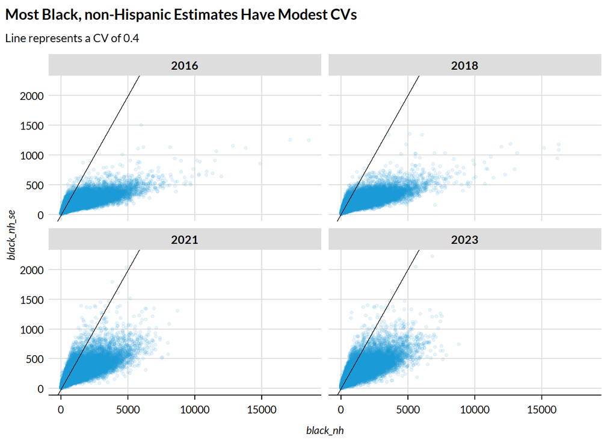

```r
tracts %>%
  ggplot(aes(black_nh, black_nh_se)) +
  geom_point(alpha = 0.1, size = 1) +
  geom_abline(aes(slope = 0.4, intercept = 0)) +
  labs(
    title = "Most Black, non-Hispanic Estimates Have Modest CVs",
    subtitle = "Line represents a CV of 0.4"
  ) +
  scatter_grid() +
  facet_wrap(. ~ year)
```

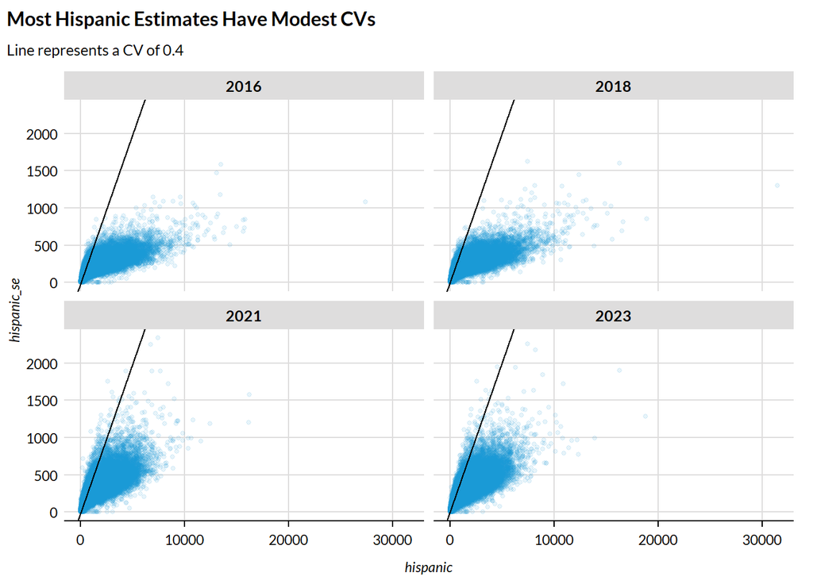

```r
tracts %>%
  ggplot(aes(hispanic, hispanic_se)) +
  geom_point(alpha = 0.1, size = 1) +
  geom_abline(aes(slope = 0.4, intercept = 0)) +
  labs(
    title = "Most Hispanic Estimates Have Modest CVs",
    subtitle = "Line represents a CV of 0.4"
  ) +
  scatter_grid() +
  facet_wrap(. ~ year)
```

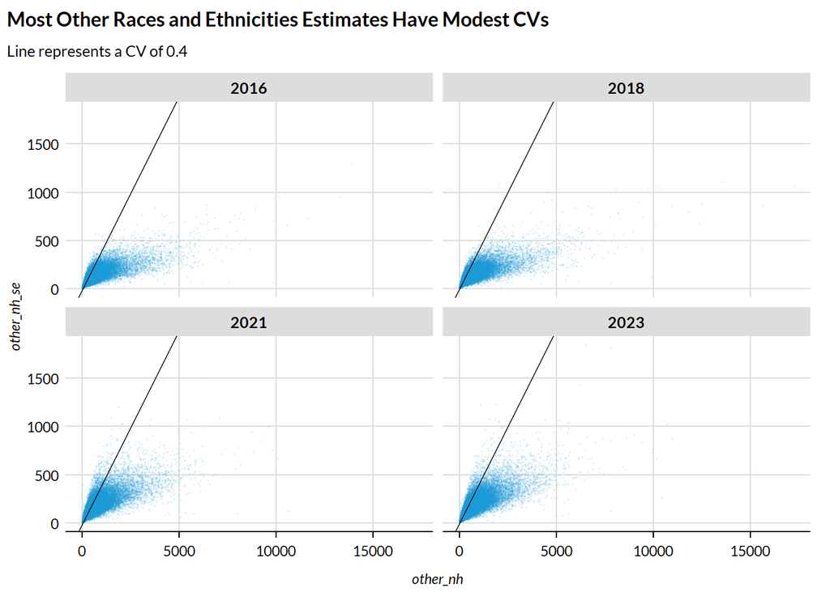

```r
tracts %>%
  ggplot(aes(other_nh, other_nh_se)) +
  geom_point(alpha = 0.1, size = 0.2) +
  geom_abline(aes(slope = 0.4, intercept = 0)) +
  labs(
    title = "Most Other Races and Ethnicities Estimates Have Modest CVs",
    subtitle = "Line represents a CV of 0.4"
  ) +
  scatter_grid() +
  facet_wrap(. ~ year)
```

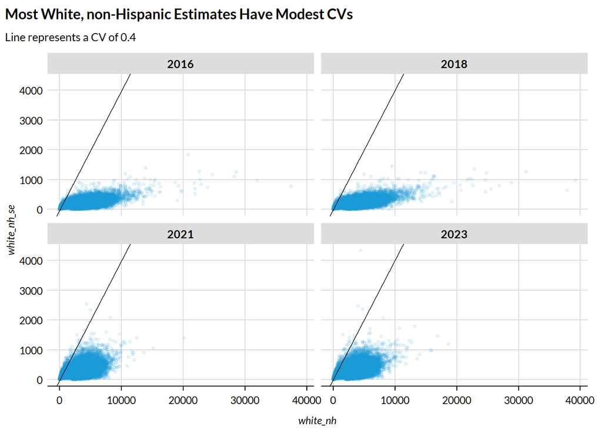

```r
tracts %>%
  ggplot(aes(white_nh, white_nh_se)) +
  geom_point(alpha = 0.1, size = 1) +
  geom_abline(aes(slope = 0.4, intercept = 0)) +
  labs(
    title = "Most White, non-Hispanic Estimates Have Modest CVs",
    subtitle = "Line represents a CV of 0.4"
  ) +
  scatter_grid() +
  facet_wrap(. ~ year)
```

## 3. Crosswalk census tracts to census places.

This metric was originally calculated at the county level. Now, we are going to calculate it for **census places**. First we read in the tract-place crosswalk and join to our tract-level data to get tract-place pairs so we can aggregate up from tracts to places.

The county-level version of this metric was more straightforward because [census tracts are completely contained within counties](https://www2.census.gov/geo/pdfs/reference/geodiagram.pdf). The place-level version will be more difficult because places are only contained within states; they do not necessarily adhere to county or tract boundaries.

Census tract populations range from [1,200 - 8,000 with an average of 4,000 inhabitants](https://www2.census.gov/geo/pdfs/education/CensusTracts.pdf). The smallest population in our list of places for 2020 is 74,793 (North Port city, FL), so all tracts are smaller than the places that we’re working with. However, “Tract 1” may be located in both “Place A” and “Place B” - therefore, we need to know what percentage of “Tract 1” area overlaps with the area of “Place A” and what percentage overlaps with the area of “Place B.” Then we can multiply the total population of “Tract 1” by those percentages to interpolate what share of that total population is located in “Place A” and what share is located in “Place B.” This is a technique known as [areal interpolation](https://cran.r-project.org/web/packages/areal/vignettes/areal-weighted-interpolation.html).

We need to know which census places have any overlap with each census tract. We read in two census-tract-to-place crosswalks that were originally downloaded from the [Missouri Census Data Center’s Geocorr tool](https://mcdc.missouri.edu/applications/geocorr2022.html). One crosswalk translates 2010-vintage tracts to 2014-vintage places (note that we use Geocorr 2018 for this crosswalk, originally), and the other translates 2020-vintage tracts to 2020-vintage places. We read these files in directly from the repository, but the process for creating them from scratch is as follows:

- Input Options
  - Select the state(s) (including DC and/or PR) to process:
    - Select all states including DC but excluding PR
  - Select one or more source geographies:
    - 2010/2020 Geographies: census tract
  - Select one or more target geographies:
    - 2014/2020 Geographies: Place (city, town, village, CDP, etc.)
  - Weighting variable:
    - Population (2010/2020 census)
  - Ignore census blocks with a value of 0 for the weighting variable: TRUE (select this option)
- Output options
  - Generate second allocation factor `[AFACT2]` showing portion of target geocodes in source geocodes

```r
## this has updated geographies for the revised (in 2022) connecticut "counties"
crosswalk_20_ct = read_csv(here::here("geographic-crosswalks", "data", "tract_crosswalk_2022_connecticut.csv")) %>%
  janitor::clean_names() %>%
  select(
    tract_fips_2020,
    tract_fips_2022)

crosswalk_20 <- read_csv(
  here::here("geographic-crosswalks", "data", "tract-place-crosswalk_2020.csv"),
  skip = 1) %>%
  select(
    state = `State code`,
    county = `County code`,
    place = `Place code`,
    tract = Tract,
    afact = `tract-to-place allocation factor`,
    afact2 = `place-to-tract allocation factor`) %>%
  mutate(
    county = substring(county, 3, 5),
    state_place = str_c(state, place),
    tract = str_remove(string = tract, pattern = "[.]")) %>%
  # place GEOIDs of 99999 indicate tracts that are not located within a
  # census place
  filter(place != 99999)

## adjusting for the revised 2022 CT counties
crosswalk_22 = crosswalk_20 %>%
  mutate(tract_fips_2020 = str_c(state, county, tract)) %>%
  left_join(crosswalk_20_ct, by = "tract_fips_2020") %>%
  mutate(
    county = case_when(
      !is.na(tract_fips_2022) ~ str_sub(tract_fips_2022, 3, 5),
      TRUE ~ county)) %>%
  select(-matches("tract_fips"))

crosswalk_10 <- read_csv(
  here::here("geographic-crosswalks", "data", "geocorr2018_2010tract_to_2014place.csv"),
  col_types = cols(
    state = col_character(),
    county= col_character(),
    placefp = col_character(),
    tract = col_character(),
    afact = col_double(),
    afact2 = col_double())) %>%
  transmute(
    state = str_pad(state, side = "left", pad = "0", width = 2),
    county = str_pad(county, side = "left", pad = "0", width = 5) %>% str_sub(3, 5),
    place = str_pad(placefp14, side = "left", pad = "0", width = 5),
    tract = str_remove(string = tract, pattern = "[.]") %>% str_pad(side = "right", pad = "0", width = 6),
    state_place = str_c(state, place),
    afact,
    afact2) %>%
  # place GEOIDs of 99999 indicate tracts that are not located within a
  # census place
  filter(place != 99999)
```

Expand the crosswalks to include a column with the years in `tracts` the crosswalk can apply to

```r
# Create a tibble for the years you want to expand
years_10 <- tibble(year = c(2016, 2018))
# Perform cross join to repeat for each year
crosswalk_10 <- crosswalk_10 |>
  crossing(years_10)

crosswalk <- bind_rows(
  crosswalk_10,
  crosswalk_20 %>% mutate(year = 2021),
  crosswalk_22 %>% mutate(year = 2023)) |>
  relocate(year, .before = everything())
```

We are only interested in places with large populations. We load the crosswalk containing those places and filter to the places of interest.

```r
places_of_interest <-
  read_csv(here::here("geographic-crosswalks", "data", "place-populations.csv")) %>%
  mutate(state_place = paste0(state, place))

crosswalk <- crosswalk %>%
  filter(state_place %in% places_of_interest$state_place)

crosswalk <-
  inner_join(
    crosswalk,
    distinct(places_of_interest, year, state_place, place_name),
    by = c("year", "state_place")
  )
```

The crosswalk contains an allocation factor variable, `afact`, which indicates the proportion of the source geographies (tracts) contained within the target geography (place). It also contains `afact2`, which is the proportion of the target geogrpahy (place) included in each source geography (tract).

We can use `afact` to allocate census tract data to places. The allocation is based on 2020 data and the ACS data uses 2021 data. We will use the product of `afact` and `afact2` for a quality measure later.

```r
crosswalk <- crosswalk %>%
  mutate(afact_product = afact * afact2)
```

Join data to match each census tract with every census place that the tract overlaps with.

```r
tracts_joined <- tidylog::left_join(tracts, crosswalk, by = c("year", "state", "county", "tract")) %>%
  arrange(state_place)
```

Many tracts are missing place because they do not overlap with any place of interest.

```r
sum(is.na(tracts_joined$state_place))
```

```
[1] 196855
```

```r
tracts_joined <- tracts_joined %>%
  filter(!is.na(state_place))
```

## 4. Calculate the share of a place’s racial/ethnic group in each tract

We weight each census tract in the numerator because only part of the tract may be in the census place. We weight the sum in the denominator to account for all of the census tracts that are only partially in the census place.

```r
indices <- tracts_joined %>%
  mutate(
    share_of_black_nh = (black_nh * afact) / sum(black_nh * afact),
    share_of_hispanic = (hispanic * afact) / sum(hispanic * afact),
    share_of_other_nh = (other_nh * afact) / sum(other_nh * afact),
    share_of_white_nh = (white_nh * afact) / sum(white_nh * afact),
    .by = c(year, state, place, state_place, place_name)
  )
```

**Check:** Do the shares in each tract sum to one in a place?

```r
stopifnot(
  indices %>%
    group_by(year, state, place, state_place) %>%
    summarize(
      share_of_black_nh = sum(share_of_black_nh),
      share_of_hispanic = sum(share_of_hispanic),
      share_of_other_nh = sum(share_of_other_nh),
      share_of_white_nh = sum(share_of_white_nh)
    ) %>%
    filter(!near(share_of_white_nh, 1) |
      !near(share_of_black_nh, 1) |
      !near(share_of_hispanic, 1) |
      !near(share_of_other_nh, 1)) %>%
    nrow() == 0
)
```

## 5. Calculate exposure to other racial/ethnic groups

- Calculate non-Hispanic Black exposure to the other groups.
- Calculate Hispanic exposure to the other groups.
- Calculate non-Hispanic white exposure to the other groups.
- Calculate Other Races and Ethnicities exposure to the other groups.

> Focusing just on whites for simplicity, we want to compute the average share of neighbors who are non-white. Thus for each census tract in a place, we need to know the percentage non-white.

Calculate the complement to each race/ethnic group of interest.

```r
indices <- indices %>%
  mutate(
    non_white_nh = (afact * (hispanic + black_nh + other_nh)) / (afact * people),
    non_black_nh = (afact * (hispanic + white_nh + other_nh)) / (afact * people),
    non_hispanic = (afact * (white_nh + black_nh + other_nh)) / (afact * people),
    non_other_nh = (afact * (hispanic + white_nh + black_nh)) / (afact * people)
  )
```

> We would then take the weighted average across tracts with the weight being the percentage of a place’s whites living in each tract. So in a place with only 2 tracts, one tract has 80 whites and only 10 percent of that residents are non-white and in the second tract there are 20 white residents but 50% of the tract is non-white, the white to non-white index would be 0.8 * 0.1 + 0.2 * 0.5 = 0.18. In other words the average white resident lives in a neighborhood in which 18% of his neighbors are non-white

We find the weighted average at the place level of exposure to other race/ethnicity groups weighted by the share of the race/ethnicity group living in each tract. In other words, the 0.1 and 0.5 are `non_white_nh` and the 0.8 and 0.2 are `share_of_white_nh`.

We account for `afact` for tracts, people, counts, and standard errors. We do not account for `afact` for the exposure variables because the tract-level variables for share of other races in the census tract (i.e. `non_black_nh`) and the share of the given race group in the tract (i.e. `share_of_black_nh`) already accounts for `afact`.

```r
place_data <- indices %>%
  summarize(
    tracts = sum(afact),
    people = sum(people * afact),
    # counts
    black_nh = sum(black_nh * afact),
    hispanic = sum(hispanic * afact),
    other_nh = sum(other_nh * afact),
    white_nh = sum(white_nh * afact),
    # standard errors
    black_nh_se = sqrt(sum(afact * (black_nh_moe^2))) / 1.645,
    hispanic_se = sqrt(sum(afact * (hispanic_moe^2))) / 1.645,
    other_nh_se = sqrt(sum(afact * (other_nh_moe^2))) / 1.645,
    white_nh_se = sqrt(sum(afact * (white_nh_moe^2))) / 1.645,
    # exposures
    share_black_nh_exposure = weighted.mean(non_black_nh, w = share_of_black_nh),
    share_hispanic_exposure = weighted.mean(non_hispanic, w = share_of_hispanic),
    share_other_nh_exposure = weighted.mean(non_other_nh, w = share_of_other_nh),
    share_white_nh_exposure = weighted.mean(non_white_nh, w = share_of_white_nh),
    afact_sum_product = sum(afact_product),
    .by = c(year, state, place, state_place, place_name)
  )
```

We don’t have data for South Fulton in 2018, but otherwise we have data for every year-place combination:

```r
place_data |>
  count(year) %>%
  rename(analysis_places = n) %>%
  left_join(
    places_of_interest %>%
      filter(year %in% years) |>
      count(year) %>%
      rename(target_places = n))
```

```
# A tibble: 4 × 3
   year analysis_places target_places
  <dbl>           <int>         <int>
1  2016             485           485
2  2018             485           486
3  2021             486           486
4  2023             486           486
```

```r
places_of_interest |>
  filter(year %in% years) |>
  anti_join(place_data, by = c("year", "state", "place"))
```

```
# A tibble: 1 × 7
   year state place state_name place_name        population state_place
  <dbl> <chr> <chr> <chr>      <chr>                  <dbl> <chr>
1  2018 13    72122 Georgia    South Fulton city      97277 1372122
```

We turn these into explicit missing values below.

```r
place_data <-
  places_of_interest |>
  filter(year %in% years) |>
  select(year, state, place, place_name, state_place) |>
  left_join(place_data, by = c("year", "state_place", "state", "place", "place_name"), relationship = "many-to-many")
```

And we now have the correct number of observations per year:

```r
place_data |>
  count(year)
```

```
# A tibble: 4 × 2
   year     n
  <dbl> <int>
1  2016   485
2  2018   486
3  2021   486
4  2023   486
```

We pull in the place-level data and compare it to the calculated place-level data. The demographic breakdowns should be identical.

```r
places_test <- map(years, ~ pull_and_rename(.x, geography = "place")) |>
  list_rbind() |>
  relocate(year, .before = everything())

places_test <- places_test %>%
  mutate(state_place = paste0(state, place)) %>%
  filter(state_place %in% places_of_interest$state_place)

# join data
test_joined <- inner_join(
  place_data,
  places_test,
  by = c("year", "state", "place", "state_place"),
  suffix = c("_interpolated", "_reported")
)
```

We can look at places with more interpolated people than reported people.

```r
test_joined %>%
  filter(people_interpolated > people_reported) %>%
  select(year, state, place, place_name, people_reported, people_interpolated) %>%
  mutate(diff = people_reported - people_interpolated) %>%
  arrange(diff) %>%
  mutate(across(where(is.numeric), round)) %>%
  reactable()
```

| year | state | place | place_name | people_reported | people_interpolated | diff |
| --- | --- | --- | --- | --- | --- | --- |
| 2021 | 48 | 65000 | San Antonio city | 1434540 | 1441084 | -6544 |
| 2021 | 48 | 35000 | Houston city | 2293288 | 2299341 | -6053 |
| 2018 | 06 | 39496 | Lake Forest city | 82911 | 88563 | -5652 |
| 2021 | 48 | 27000 | Fort Worth city | 908469 | 913212 | -4743 |
| 2021 | 06 | 27000 | Fresno city | 538678 | 543115 | -4437 |
| 2018 | 49 | 57300 | Orem city | 95428 | 99865 | -4437 |
| 2018 | 06 | 60466 | Rialto city | 102873 | 106203 | -3330 |
| 2021 | 48 | 19000 | Dallas city | 1300239 | 1303554 | -3315 |
| 2023 | 48 | 35000 | Houston city | 2300419 | 2303626 | -3207 |
| 2016 | 48 | 70808 | Sugar Land city | 85681 | 88790 | -3109 |

[output cut: 686 more lines]

We can look at places with fewer interpolated people than reported people.

```r
test_joined %>%
  filter(people_interpolated < people_reported) %>%
  select(year, state, place, place_name, people_reported, people_interpolated) %>%
  mutate(diff = people_reported - people_interpolated) %>%
  arrange(desc(diff)) %>%
  mutate(across(where(is.numeric), round)) %>%
  reactable()
```

| year | state | place | place_name | people_reported | people_interpolated | diff |
| --- | --- | --- | --- | --- | --- | --- |
| 2016 | 21 | 48006 | Louisville/Jefferson County metro government (balance) | 611573 | 363984 | 247589 |
| 2021 | 21 | 48006 | Louisville/Jefferson County metro government (balance) | 630260 | 383376 | 246884 |
| 2018 | 21 | 48006 | Louisville/Jefferson County metro government (balance) | 617032 | 371187 | 245845 |
| 2023 | 21 | 48006 | Louisville/Jefferson County metro government (balance) | 627210 | 386830 | 240380 |
| 2018 | 06 | 69088 | Santa Clarita city | 209478 | 178076 | 31402 |
| 2018 | 04 | 77000 | Tucson city | 539216 | 512360 | 26856 |
| 2018 | 48 | 70808 | Sugar Land city | 118182 | 93925 | 24257 |
| 2018 | 31 | 37000 | Omaha city | 465112 | 441993 | 23119 |
| 2016 | 04 | 77000 | Tucson city | 527586 | 511420 | 16166 |
| 2023 | 48 | 42508 | Lewisville city | 128313 | 114175 | 14138 |

[output cut: 899 more lines]

We visualize to compare.

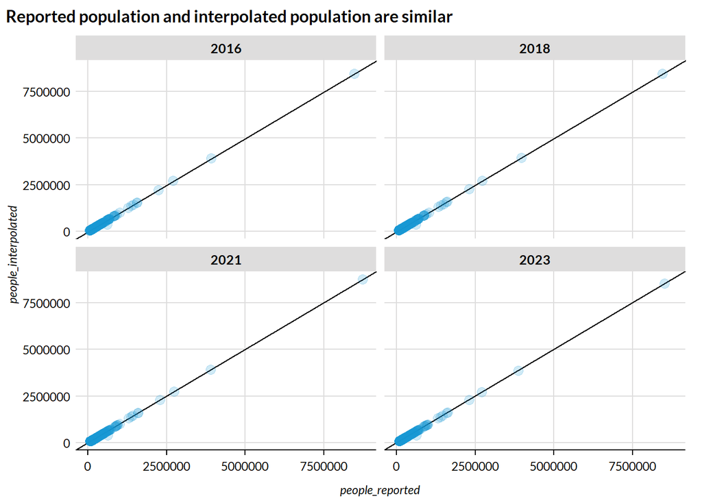

```r
test_joined <- test_joined %>%
  mutate(
    pop_lt_200000 = if_else(people_interpolated < 200000,
      "Pop. < 200,000",
      "Pop. > 200,000"
    )
  )

test_joined %>%
  ggplot(aes(people_reported, people_interpolated)) +
  geom_abline() +
  geom_point(alpha = 0.2) +
  facet_wrap(~pop_lt_200000, scales = "free") +
  scatter_grid() +
  labs(title = "Reported population and interpolated population are similar") +
  facet_wrap(. ~ year)
```

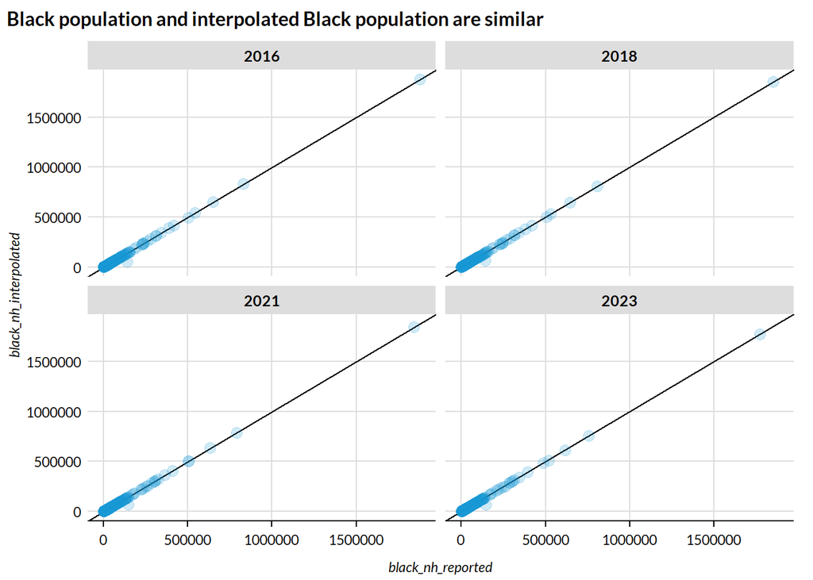

```r
test_joined %>%
  ggplot(aes(black_nh_reported, black_nh_interpolated)) +
  geom_abline() +
  geom_point(alpha = 0.2) +
  facet_wrap(~pop_lt_200000, scales = "free") +
  scatter_grid() +
  labs(title = "Black population and interpolated Black population are similar") +
  facet_wrap(. ~ year)
```

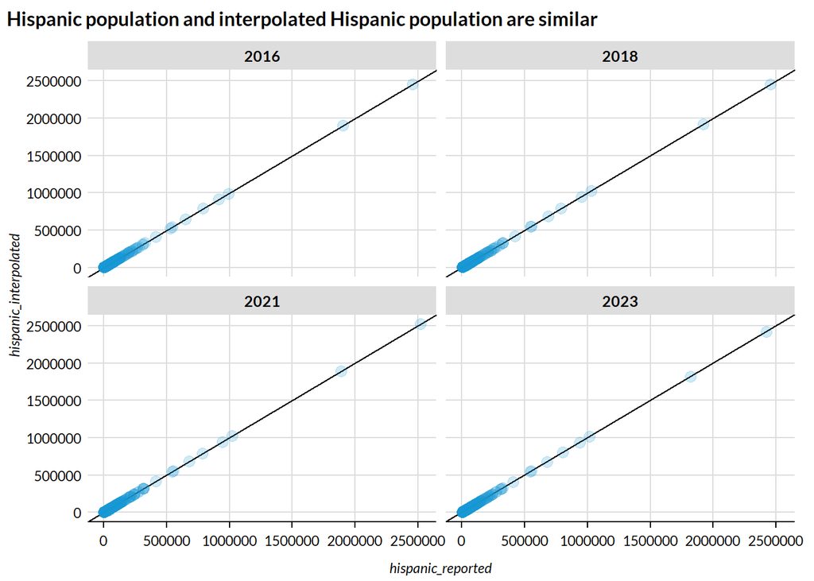

```r
test_joined %>%
  ggplot(aes(hispanic_reported, hispanic_interpolated)) +
  geom_abline() +
  geom_point(alpha = 0.2) +
  facet_wrap(~pop_lt_200000, scales = "free") +
  scatter_grid() +
  labs(title = "Hispanic population and interpolated Hispanic population are similar") +
  facet_wrap(. ~ year)
```

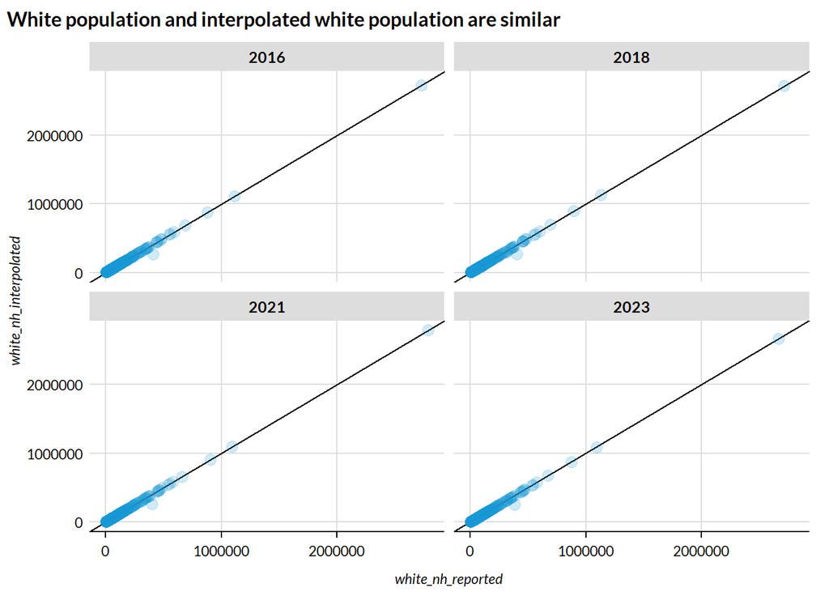

```r
test_joined %>%
  ggplot(aes(white_nh_reported, white_nh_interpolated)) +
  geom_abline() +
  geom_point(alpha = 0.2) +
  facet_wrap(~pop_lt_200000, scales = "free") +
  scatter_grid() +
  labs(title = "White population and interpolated white population are similar") +
  facet_wrap(. ~ year)
```

## 6. Validation

The table shows the calculated metrics. Click on the variable columns to sort the table.

| year | state | place | place_name | tracts | black_nh | hispanic | other_nh | white_nh | black_nh_exp | hispanic_exp | other_nh_exp | white_nh_exp |
| --- | --- | --- | --- | --- | --- | --- | --- | --- | --- | --- | --- | --- |
| 2016 | 01 | 03076 | Auburn city | 11.238 | 11043.276 | 3198.389 | 4626.802 | 40472.468 | 0.725 | 0.907 | 0.903 | 0.296 |
| 2016 | 01 | 07000 | Birmingham city | 64.888 | 147902.825 | 7816.866 | 4652.998 | 51228.427 | 0.177 | 0.903 | 0.947 | 0.459 |
| 2016 | 01 | 35896 | Hoover city | 15.883 | 14510.112 | 4737.512 | 5991.526 | 59847.537 | 0.729 | 0.867 | 0.913 | 0.243 |
| 2016 | 01 | 37000 | Huntsville city | 48.691 | 55811.211 | 10324.229 | 10179.595 | 110852.892 | 0.456 | 0.853 | 0.93 | 0.268 |
| 2016 | 01 | 50000 | Mobile city | 66.902 | 95887.052 | 5423.612 | 6529.048 | 87016.823 | 0.327 | 0.949 | 0.938 | 0.384 |
| 2016 | 01 | 51000 | Montgomery city | 55.27 | 118577.888 | 6609.205 | 8309.425 | 68309.965 | 0.286 | 0.869 | 0.893 | 0.478 |
| 2016 | 01 | 77256 | Tuscaloosa city | 24.25 | 41121.141 | 3227.609 | 3432.35 | 46832.632 | 0.337 | 0.926 | 0.917 | 0.339 |
| 2016 | 02 | 03000 | Anchorage municipality | 55 | 15902 | 26091 | 78200 | 179128 | 0.916 | 0.895 | 0.68 | 0.36 |
| 2016 | 04 | 04720 | Avondale city | 19.039 | 8047.983 | 40550.098 | 4856.44 | 26582.942 | 0.885 | 0.441 | 0.923 | 0.613 |
| 2016 | 04 | 07940 | Buckeye city | 9.122 | 4008.186 | 19530.481 | 2281.168 | 31612.814 | 0.915 | 0.625 | 0.943 | 0.421 |

[output cut: 1933 more lines]

**Check:** Is the metric bounded by 0 and 1?

```r
stopifnot(
  place_data %>%
    filter(share_white_nh_exposure > 1 | share_white_nh_exposure < 0 |
      share_black_nh_exposure > 1 | share_black_nh_exposure < 0 |
      share_hispanic_exposure > 1 | share_hispanic_exposure < 0 |
      share_other_nh_exposure > 1 | share_other_nh_exposure < 0) %>%
    nrow() == 0
)
```

**Check:** Do groups with zero representation in a place have an `NA` for the exposure metric?

```r
stopifnot(
  place_data %>%
    filter(black_nh == 0 & !is.na(share_black_nh_exposure)) %>%
    nrow() == 0
)

stopifnot(
  place_data %>%
    filter(hispanic == 0 & !is.na(share_hispanic_exposure)) %>%
    nrow() == 0
)

stopifnot(
  place_data %>%
    filter(other_nh == 0 & !is.na(share_other_nh_exposure)) %>%
    nrow() == 0
)

stopifnot(
  place_data %>%
    filter(white_nh == 0 & !is.na(share_white_nh_exposure)) %>%
    nrow() == 0
)
```

**Check:** How many missing values are there?

Values are missing where the count in the racial group is 0. For example, `share_black_nh_exposure` is `NA` when `black_nh == 0`.

```r
map_dbl(place_data, ~ sum(is.na(.)))
```

```
                   year                   state                   place
                      0                       0                       0
             place_name             state_place                  tracts
                      0                       0                       1
                 people                black_nh                hispanic
                      1                       1                       1
               other_nh                white_nh             black_nh_se
                      1                       1                       1
            hispanic_se             other_nh_se             white_nh_se
                      1                       1                       1
share_black_nh_exposure share_hispanic_exposure share_other_nh_exposure
                      1                       1                       1
share_white_nh_exposure       afact_sum_product
                      1                       1
```

Let’s visualize the relationship between a group’s share of the population in a place and the calculated exposure metric.

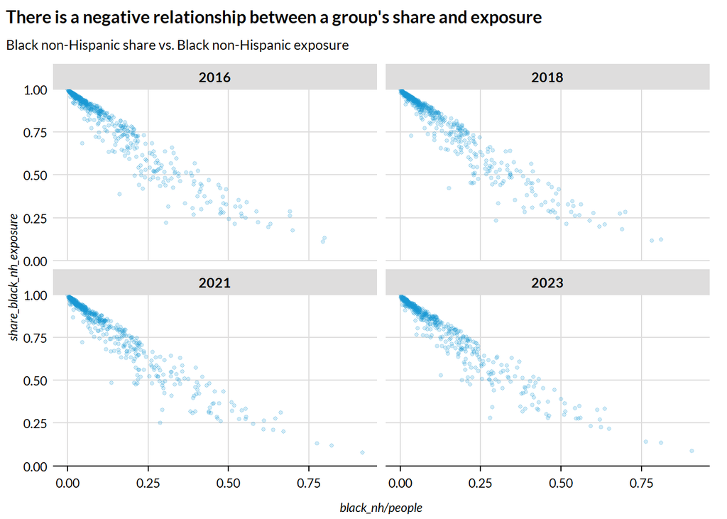

```r
place_data %>%
  ggplot(aes(black_nh / people, share_black_nh_exposure)) +
  geom_point(
    alpha = 0.2,
    size = 1
  ) +
  scale_y_continuous(
    expand = c(0, 0),
    limits = c(0, 1)
  ) +
  labs(
    title = "There is a negative relationship between a group's share and exposure",
    subtitle = "Black non-Hispanic share vs. Black non-Hispanic exposure"
  ) +
  scatter_grid() +
  facet_wrap(. ~ year)
```

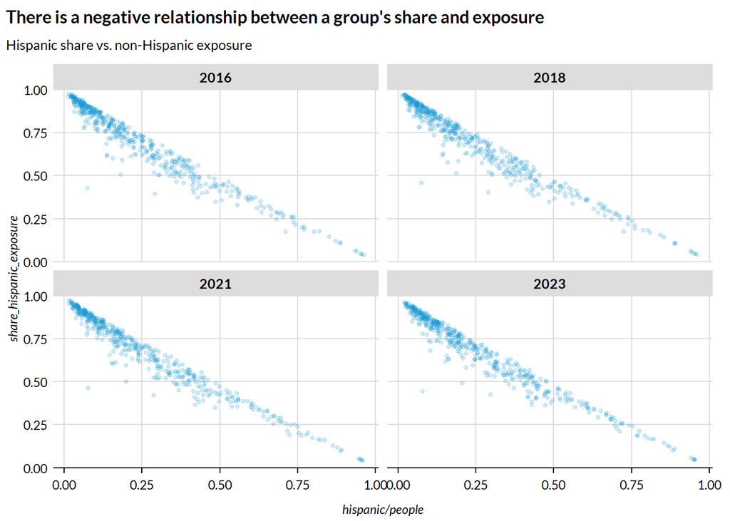

```r
place_data %>%
  ggplot(aes(hispanic / people, share_hispanic_exposure)) +
  geom_point(
    alpha = 0.2,
    size = 1
  ) +
  scale_y_continuous(
    expand = c(0, 0),
    limits = c(0, 1)
  ) +
  labs(
    title = "There is a negative relationship between a group's share and exposure",
    subtitle = "Hispanic share vs. non-Hispanic exposure"
  ) +
  scatter_grid() +
  facet_wrap(. ~ year)
```

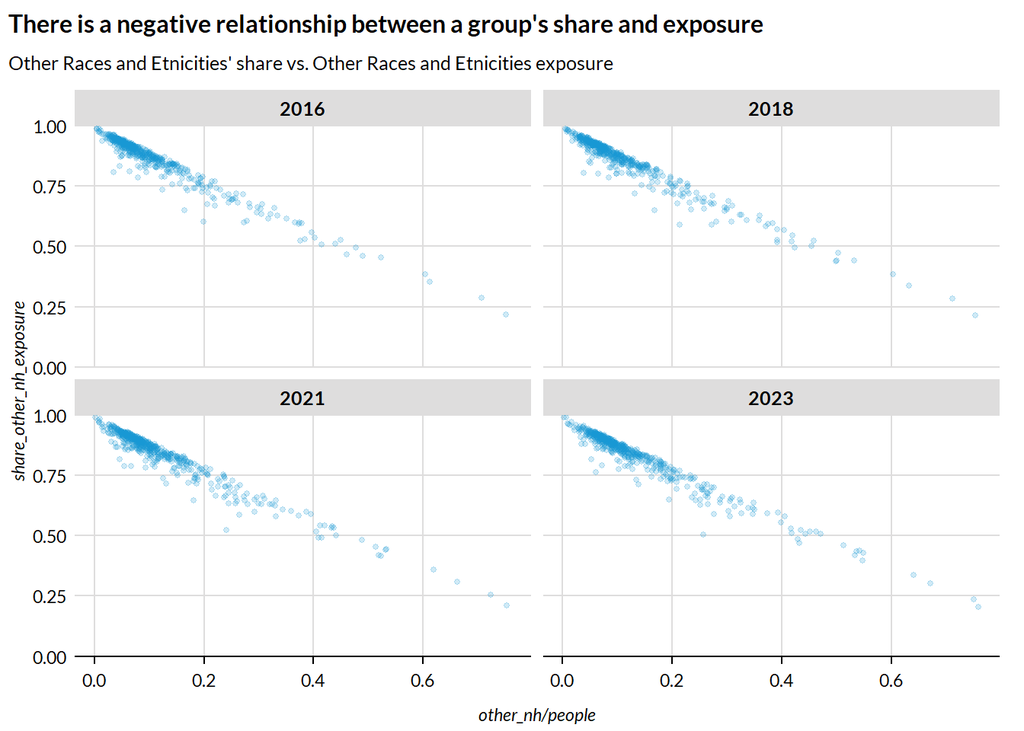

```r
place_data %>%
  ggplot(aes(other_nh / people, share_other_nh_exposure)) +
  geom_point(
    alpha = 0.2,
    size = 1
  ) +
  scale_y_continuous(
    expand = c(0, 0),
    limits = c(0, 1)
  ) +
  labs(
    title = "There is a negative relationship between a group's share and exposure",
    subtitle = "Other Races and Etnicities' share vs. Other Races and Etnicities exposure"
  ) +
  scatter_grid() +
  facet_wrap(. ~ year)
```

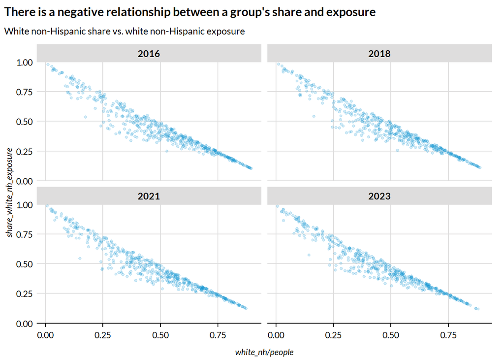

```r
place_data %>%
  ggplot(aes(white_nh / people, share_white_nh_exposure)) +
  geom_point(
    alpha = 0.2,
    size = 1
  ) +
  scale_y_continuous(
    expand = c(0, 0),
    limits = c(0, 1)
  ) +
  labs(
    title = "There is a negative relationship between a group's share and exposure",
    subtitle = "White non-Hispanic share vs. white non-Hispanic exposure"
  ) +
  scatter_grid() +
  facet_wrap(. ~ year)
```

## 7. Add Data Quality Flags

We consider three dimensions of quality when developing the quality variables for poverty exposure.

1. The unweighted number of observations behind each calculation.
2. The coefficient of variation for poverty in the census place.
3. The overlap of census place (target geography) and the census tracts (source geographies).

### 1. Unweighted number of observations

```r
#' Suppress places
#'
#' @param race The variable for the count in a race/ethnicity group
#' @param exposure The variable name for the exposure index
#' @param threshold The minimum size of the race group to report the exposure index
#'
#' @return
#'
suppress_place <- function(race, exposure, threshold) {
  exposure <- if_else(race <= threshold, as.numeric(NA), exposure)

  return(exposure)
}

place_data %>%
  summarize(
    share_black_nh_exposure = sum(is.na(share_black_nh_exposure)),
    share_hispanic_exposure = sum(is.na(share_hispanic_exposure)),
    share_other_nh_exposure = sum(is.na(share_other_nh_exposure)),
    share_white_nh_exposure = sum(is.na(share_white_nh_exposure)),
    .by = c(year)
  )
```

```
# A tibble: 4 × 5
   year share_black_nh_exposure share_hispanic_exposure share_other_nh_exposure
  <dbl>                   <int>                   <int>                   <int>
1  2016                       0                       0                       0
2  2018                       1                       1                       1
3  2021                       0                       0                       0
4  2023                       0                       0                       0
# ℹ 1 more variable: share_white_nh_exposure <int>
```

```r
place_data <- place_data %>%
  mutate(
    share_black_nh_exposure = suppress_place(black_nh, share_black_nh_exposure, threshold = 30),
    share_hispanic_exposure = suppress_place(hispanic, share_hispanic_exposure, threshold = 30),
    share_other_nh_exposure = suppress_place(other_nh, share_other_nh_exposure, threshold = 30),
    share_white_nh_exposure = suppress_place(white_nh, share_white_nh_exposure, threshold = 30)
  )

place_data %>%
  summarize(
    black_nh = sum(is.na(share_black_nh_exposure)),
    hispanic = sum(is.na(share_hispanic_exposure)),
    other_nh = sum(is.na(share_other_nh_exposure)),
    white_nh = sum(is.na(share_white_nh_exposure)),
    .by = c(year)
  )
```

```
# A tibble: 4 × 5
   year black_nh hispanic other_nh white_nh
  <dbl>    <int>    <int>    <int>    <int>
1  2016        1        0        0        0
2  2018        2        1        1        1
3  2021        0        0        0        0
4  2023        0        0        0        0
```

### 2. Coefficient of variation

The coefficient of variation is a standard measure of precision normalized by the magnitude of an estimate. In this case it is $\frac{SE(\hat{count})}{\hat{count}}$. We calculate the coefficient of variation for each poverty estimate.

We don’t calculate the CV at the tract-level or for high poverty.

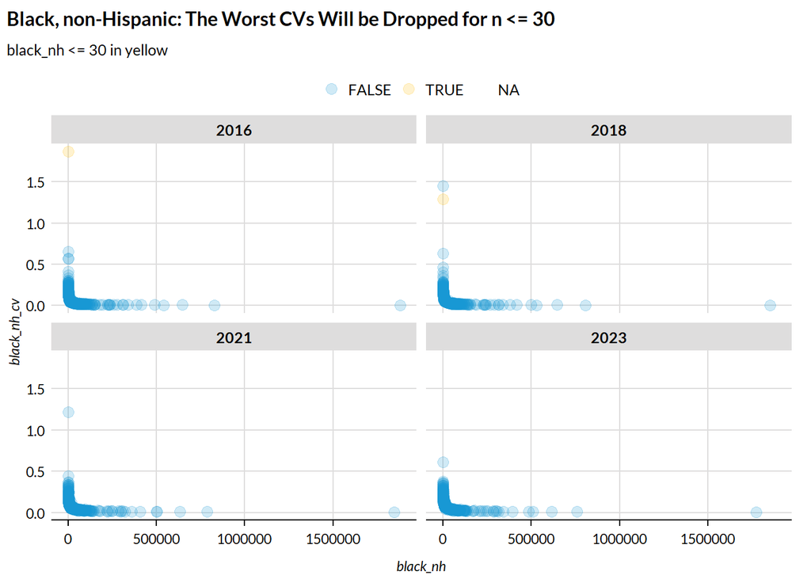

```r
place_data <- place_data %>%
  mutate(
    black_nh_cv = black_nh_se / black_nh,
    hispanic_cv = hispanic_se / hispanic,
    other_nh_cv = other_nh_se / other_nh,
    white_nh_cv = white_nh_se / white_nh
  )

place_data %>%
  ggplot(aes(black_nh, black_nh_cv, color = black_nh <= 30)) +
  geom_point(alpha = 0.2) +
  labs(
    title = "Black, non-Hispanic: The Worst CVs Will be Dropped for n <= 30",
    subtitle = "black_nh <= 30 in yellow"
  ) +
  scatter_grid() +
  facet_wrap(. ~ year)
```

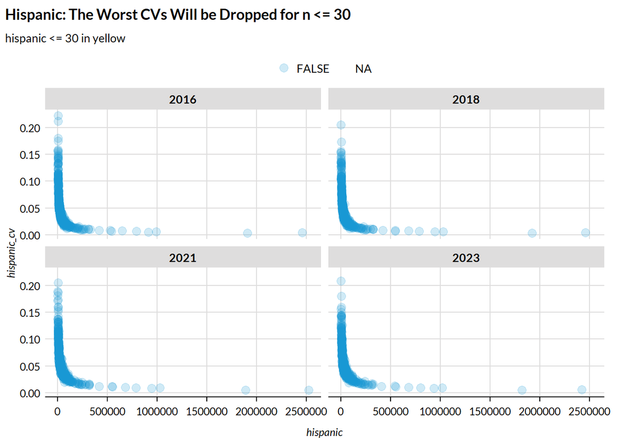

```r
place_data %>%
  ggplot(aes(hispanic, hispanic_cv, color = hispanic <= 30)) +
  geom_point(alpha = 0.2) +
  labs(
    title = "Hispanic: The Worst CVs Will be Dropped for n <= 30",
    subtitle = "hispanic <= 30 in yellow"
  ) +
  scatter_grid() +
  facet_wrap(. ~ year)
```

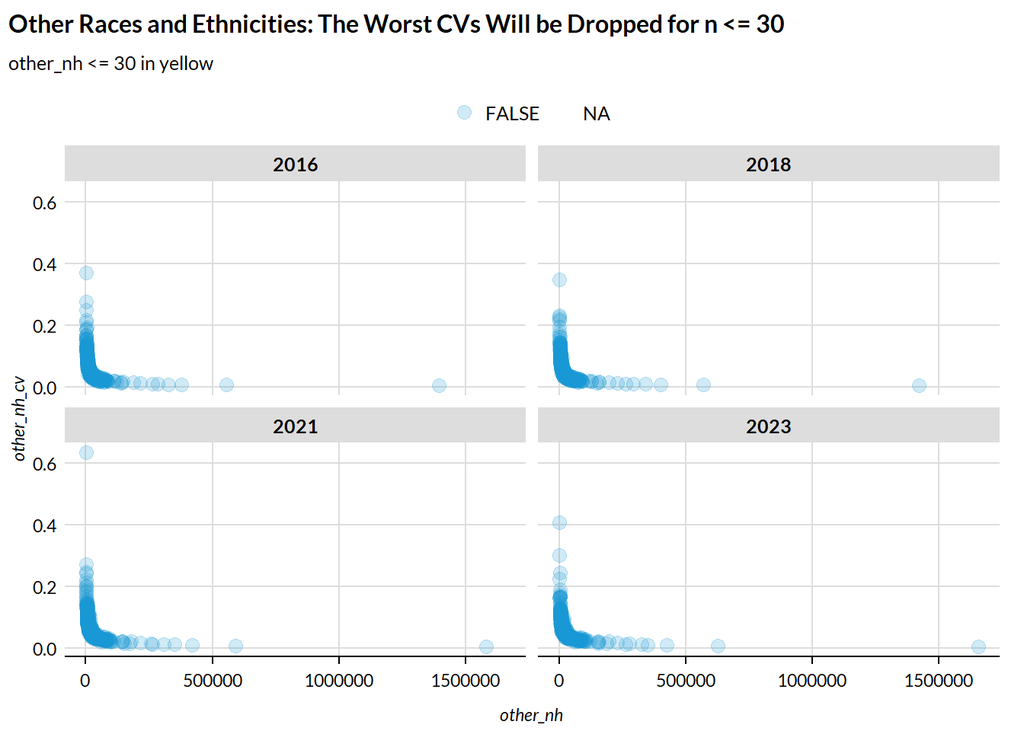

```r
place_data %>%
  ggplot(aes(other_nh, other_nh_cv, color = other_nh <= 30)) +
  geom_point(alpha = 0.2) +
  labs(
    title = "Other Races and Ethnicities: The Worst CVs Will be Dropped for n <= 30",
    subtitle = "other_nh <= 30 in yellow"
  ) +
  scatter_grid() +
  facet_wrap(. ~ year)
```

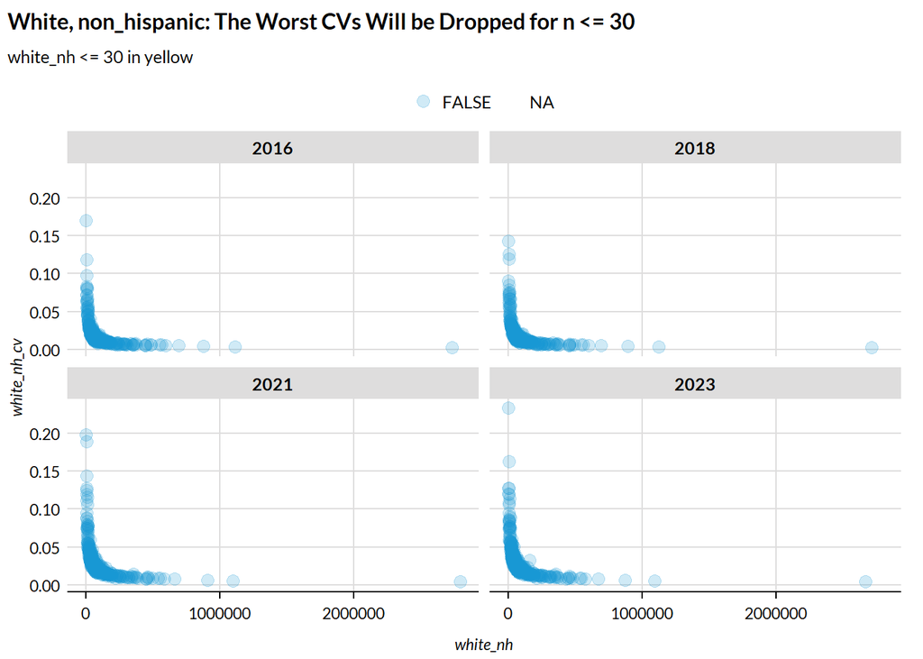

```r
place_data %>%
  ggplot(aes(white_nh, white_nh_cv, color = white_nh <= 30)) +
  geom_point(alpha = 0.2) +
  labs(
    title = "White, non_hispanic: The Worst CVs Will be Dropped for n <= 30",
    subtitle = "white_nh <= 30 in yellow"
  ) +
  scatter_grid() +
  facet_wrap(. ~ year)
```

### 3. Overlap between census tracts and census places

Areal interpolation reduces the precision of our estimates. The visualizations above demonstrate that there is a tight connection between our interpolated estimates and the estimates reported directly at the census place level.

We still develop a measure of the amount of data shared by the target geography and source geographies. We use an approach developed by Greg Acs and Kevin Werner for other spatial interpolations. The idea is to weight the proportion of tract data in a census place by the proportion of the census place in the tract. Consider a few examples:

- If `afact` and `afact2` are both 1, then the census tract and census place share the same borders.
- If `afact` is < 1 and `afact2` is 1, the census tract spans the place but the place is entirely in the tract. This is impossible.
- If `afact` is 1 and `afact2` is < 1, then the census place is spread over multiple tracts. `afact` and `afact2` are multiplied together and summed for each instance of the place. So if the place is spread perfectly among two tracts, `afact2` will be 0.5 for each row, the product of `afact` and `afact2` will be 0.5, and the sum will 1 one, meaning we know where 100% of the places’s data comes from.
- If both `afact` and `afact2` are < 1, then the result is a combination of previous two examples. There will be multiple instances of rows to be summed, but the total sum will likely be less than 1.

We performed these calculations above.

All proportions exceed 0.75. This indicates that there is a tight connection between the census tracts and the census places. This unsurprising since we only focus on census places with large populations.

```r
summary(place_data$afact_sum_product)
```

```
   Min. 1st Qu.  Median    Mean 3rd Qu.    Max.    NA's
 0.7634  0.9305  0.9693  0.9552  0.9942  1.0008       1
```

We need to add data quality flags with `1`, `2`, or `3`. The values are outlined in the [data standards](https://github.com/UI-Research/gates-mobility-metrics).

- `1` - If the place coefficient of variation for the count in the group is less than 0.2
- `2` - If the place coefficient of variation for the count in the group is less than 0.4
- `3` - If the place coefficient of variation for the count in the group exceeds 0.4 but the value is not `NA`
- `NA` - If the metric is missing

```r
#' Assign a data quality flag
#'
#' @param race A vector of counts of a race/ethnicity group within a place
#' @param exposure A race/ethnicity exposure metric
#'
#' @return A numeric data quality flag
#'
set_quality <- function(cv, exposure) {
  quality <- case_when(
    cv < 0.2 ~ 1,
    cv < 0.4 ~ 2,
    cv >= 0.4 ~ 3
  )
  quality <- if_else(is.na(exposure), as.numeric(NA), quality)

  return(quality)
}

place_data <- place_data %>%
  mutate(
    share_black_nh_exposure_quality = set_quality(cv = black_nh_cv, exposure = share_black_nh_exposure),
    share_hispanic_exposure_quality = set_quality(cv = hispanic_cv, exposure = share_hispanic_exposure),
    share_other_nh_exposure_quality = set_quality(cv = other_nh_cv, exposure = share_other_nh_exposure),
    share_white_nh_exposure_quality = set_quality(cv = white_nh_cv, exposure = share_white_nh_exposure)
  )

count(place_data, share_black_nh_exposure_quality)
```

```
# A tibble: 4 × 2
  share_black_nh_exposure_quality     n
                            <dbl> <int>
1                               1  1779
2                               2   150
3                               3    11
4                              NA     3
```

```r
count(place_data, share_hispanic_exposure_quality)
```

```
# A tibble: 3 × 2
  share_hispanic_exposure_quality     n
                            <dbl> <int>
1                               1  1937
2                               2     5
3                              NA     1
```

```r
count(place_data, share_other_nh_exposure_quality)
```

```
# A tibble: 4 × 2
  share_other_nh_exposure_quality     n
                            <dbl> <int>
1                               1  1920
2                               2    20
3                               3     2
4                              NA     1
```

```r
count(place_data, share_white_nh_exposure_quality)
```

```
# A tibble: 3 × 2
  share_white_nh_exposure_quality     n
                            <dbl> <int>
1                               1  1941
2                               2     1
3                              NA     1
```

There is very limited missingness.

```r
missing <- place_data %>%
  filter(
    is.na(share_black_nh_exposure) |
      is.na(share_hispanic_exposure) |
      is.na(share_other_nh_exposure) |
      is.na(share_white_nh_exposure)
  )

nrow(missing)
```

```
[1] 3
```

## 8. Save the Data

```r
place_data %>%
  select(
    year,
    state,
    place,
    share_black_nh_exposure,
    share_black_nh_exposure_quality,
    share_hispanic_exposure,
    share_hispanic_exposure_quality,
    share_other_nh_exposure,
    share_other_nh_exposure_quality,
    share_white_nh_exposure,
    share_white_nh_exposure_quality
  ) %>%
  write_csv(here::here("06_neighborhoods", "race-ethnicity-exposure", "final", "race-ethnicity-exposure-city.csv"))
```

## Testing

```r
final_data <- read_csv(here::here("06_neighborhoods", "race-ethnicity-exposure",
                                  "final", "race-ethnicity-exposure-city.csv"),
                       show_col_types = FALSE)

evaluate_final_data(
  exp_form_path = "10a_final-evaluation/evaluation_form_share_race_exposure_overall_place.csv",
  data = final_data, geography = "place",
  subgroups = FALSE, confidence_intervals = FALSE
)
```

```
[1] "This data passes all tests!"
```